# ETC5513: Collaborative and Reproducible Practices

# Cross-referencing and academic referencing

In this exercise you will learn how to reference figures, tables and sections in your report. We will also learn how to cite external sources.

1. Open the file `week4.qmd` and add the following to the end of the document:

````markdown
```{r}
#| label: fig-penguins
#| fig-cap: "Bill length vs bill depth of three species of penguins from the Palmer Station, Antarctica"

library(palmerpenguins)

ggplot(penguins, aes(x=bill_length_mm, y=bill_depth_mm, colour=species)) +
  geom_point()
```
````

2. Add a sentence below this chunk that says: `@fig-penguins shows that the three species of penguins have clusters of bill depths and bill lengths that largely do not overlap`
3. Render the document. You should see a hyperlink to Figure 1, that links back to your original figure.

# Home extension: Academic referencing

With Quarto, we no longer need to type out references manually. With the help of some external software, our external references can be automatically generated.

**Tip**

If you get stuck on this section, check out the video on Moodle.

1. Download Zotero: https://www.zotero.org/ and register for a free account.
2. Install the Better BibTeX for Zotero extension: https://retorque.re/zotero-better-bibtex/installation/
3. Install the relevant Connector for your web browser: https://www.zotero.org/download/connectors
4. We will add the reference by it’s *Digial Object Identifier* or DOI. The DOI for `palmerpenguins` is 10.5281/zenodo.3960218. Press the small “Add item by identifier” button in Zotero, and paste in the DOI:

[figure not shown]

5. In Zotero, right click the newly added item, go to “Better BibTex” -> “copy BibTeX to clipboard”

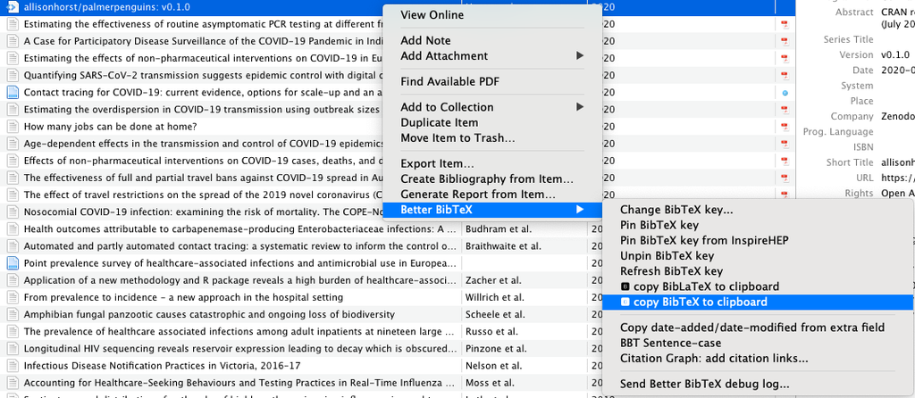

6. Inside your project, create a new file called `references.bib`. Paste the BibTeX you just copied in there. It should look something like this:

```
@misc{horstAllisonhorstPalmerpenguinsV0102020,
  title = {Allisonhorst/Palmerpenguins: V0.1.0},
  shorttitle = {Allisonhorst/Palmerpenguins},
  author = {Horst, Allison M and Hill, Alison Presmanes and Gorman, Kristen B},
  year = {2020},
  month = jul,
  doi = {10.5281/ZENODO.3960218},
  urldate = {2025-03-24},
  abstract = {CRAN release of palmerpenguins v0.1.0 R package by Horst, Hill and Gorman (July 2020).},
  copyright = {Open Access},
  howpublished = {Zenodo}
}
```

7. In `week4.qmd`, add the following to the YAML:

```
bibliography: references.bib
```

8. In the sentence we wrote describing Figure 1, add the following to the end of the sentence: `@horstAllisonhorstPalmerpenguinsV0102020`.
9. Re-render the document. You should have a reference to the package where you typed `@horstAllisonhorstPalmerpenguinsV0102020`, and you should see a references section at the end of the document.